# Introduction

Central Bank, Interest Rates, and the Economy

```
flowchart LR
  A[Fed Funds Rate] --> B[Treasury Yields]
  B --> C(Treasury Bill)
  C --> D(3 Months Bill)
  C --> E(6 Months Bill)
  C --> F(1 Year Bill)
  D --> OI(Short Term Economic Trend)
  E --> OI
  F --> OI
  B --> G(Treasury Note)
  G --> H(5 Year Note)
  G --> I(10 Year Note)
  B --> J(Treasury Bond)
  J --> K(20 Year Bond)
  J --> L(30 Year Bond)
  K --> M(30 Year Mortgage Rate)
  L --> M
  A --> A1[Macro-Economy]
  A1 --> A2(GDP)
  A2 --> A4(Consumption)
  A4 --> A8(CPI)
  A4 --> A9(Consumer Sentiment)
  A2 --> A6(Govt Spending)
  A2 --> A5(Investment)
  A2 --> A7(Net Export)
  A7 --> A10(US Dollar Index)
  A1 --> A11(Unemployment Rate)
  A1 --> A12(Stock Market)
  A12 --> A13(S&P 500)
  A8 --> A14(Long Term Economic Trend)
  A9 --> A14(Long Term Economic Trend)
  A6 --> A14(Long Term Economic Trend)
  A5 --> A14(Long Term Economic Trend)
  A10 --> A14(Long Term Economic Trend)
  A13 --> A14(Long Term Economic Trend)
  M --> A14(Long Term Economic Trend)
```

### Central Bank

The Central Bank, widely acknowledged as a preeminent authority in the financial sector, exercises profound influence over the economy. In an era of global interconnectivity, even minute actions by central banks can reverberate across distant economies. Therefore, it is imperative to examine their roles, tools, and execution. Well-known central banks include **The Federal Reserve System (the Fed)**, the Bank of England, the European Central Bank (ECB).

### Interest Rate

Interest rates are central banks’ potent tools that play a significant role in the domestic and global economy. As depicted in the flow chart, when interest rates are raised, it leads to a short-term reduction in consumption, investment, government spending, and net exports, resulting in GDP contraction. However, in the long term, it tends to curb inflation. Conversely, when interest rates are lowered, the opposite effect occurs, stimulating economic activity. This illustrates how central banks manipulate interest rates to influence economic conditions.

### Fed Funds Rate

The Fed Funds Rate, set by the U.S. Federal Reserve, is the rate at which banks lend to each other overnight and significantly influences other interest rates in the economy, including those of Treasury securities. When the Fed changes this rate, it impacts borrowing costs, affecting spending and investment throughout the economy. This shift alters demand for Treasury securities, changing their yields and subsequently influencing the shape of the Treasury Yield Curve, which is viewed as an indicator of future economic conditions. In essence, the Fed Funds Rate indirectly sways the Treasury securities market and the broader economic outlook through its influence on borrowing costs and investment.

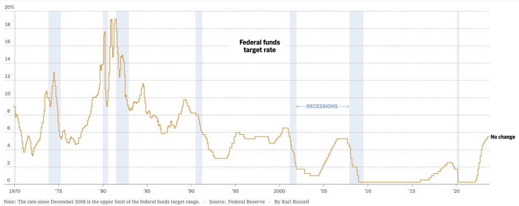

[Link](https://www.nytimes.com/live/2023/09/20/business/fed-meeting-interest-rates)

### Gross Domestic Product

GDP = Consumption + Investment + Government Spending + Net Exports

The Federal Reserve’s adjustments to the Federal Funds Rate, the interest rate at which banks lend to each other overnight, wield significant influence over the broader economy. When the Fed raises this rate, borrowing costs throughout the economy tend to rise, often dampening spending and investment and subsequently slowing economic growth, while potentially curbing inflation. Conversely, when the Fed lowers the rate, borrowing generally becomes less costly, encouraging spending and investment, potentially boosting economic growth but also risking heightened inflation. Therefore, the Fed’s policy decisions on the Federal Funds Rate carefully navigate between stimulating economic activity and maintaining control over inflation.

### Risk-Free Rate

The risk-free rate refers to the expected return of an investment that bears no risk, unaffected by factors like inflation. Widely recognized benchmarks, such as the London Interbank Offered Rate (LIBOR) and the U.S. Treasury Bond Yield Curve, are often associated with this rate due to their strong economic backing and perceived low-risk nature.

### U.S. Treasury Securities

U.S. Treasury securities, encompassing Treasury Bills (T-Bills), Treasury Bonds, and Treasury Notes, are pivotal financial instruments utilized by the federal government for capital-raising to fund its obligations. T-Bills, with maturities ranging from four to fifty-two weeks, are sold at a discount and are considered ultra short-term; Treasury Bonds have a much longer maturity of up to thirty years, and Treasury Notes feature mid-range maturities between two and ten years. Both bonds and notes pay semi-annual interest. Backed by the U.S. government’s credit, these securities are deemed low-risk, making them appealing to investors seeking capital preservation, especially in economically uncertain times. T-Bills, often utilized as a benchmark in financial markets, hold particular significance due to their inherent stability and impact on various economic metrics and monetary policy.

### Treasury Yield Curve

The Treasury Yield Curve is a graph that shows the interest rates of U.S. government bonds and how they change for different time periods. Imagine a line that usually goes up, meaning investors get higher interest if they agree to lend money for a longer time. This line can provide hints about future economic conditions. If the line flips and goes down, meaning short-term interest rates are higher than long-term ones, it might suggest economic trouble ahead. People watch this curve because it helps them guess what might happen with interest rates and the economy in the future.

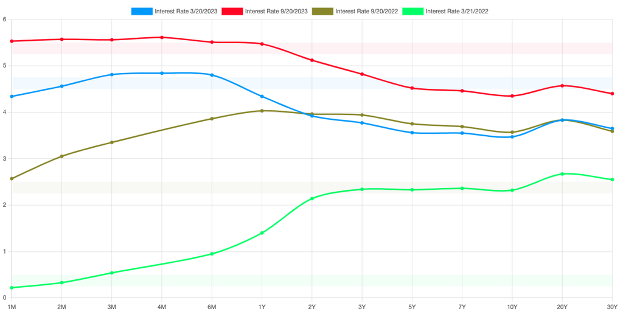

[Link](https://www.ustreasuryyieldcurve.com/)

### Summary

The interest rate serves as a pivotal tool in the Federal Reserve’s arsenal for regulating economic conditions. A key concept within this realm is the risk-free rate, which denotes an interest rate shielded from external risks and exposures. Typically, market participants turn to benchmarks such as LIBOR or the Treasury Bill (T-Bill) interest rate when seeking a risk-free rate, primarily due to their inherently low risk profile. Notably, the T-Bill rate is not a fixed figure prescribed by the Treasury Department; instead, it fluctuates in accordance with the prices of various T-Bills traded on the secondary market.

However, a common query arises: If the market determines the risk-free rate, why do people frequently attribute changes in interest rates to actions taken by the Federal Reserve? The answer lies in the Federal Reserve’s influence over the overnight interest rate, known as the Fed Funds Rate. This rate plays a significant role in the yield curve, particularly when examining the curve at a very short-term horizon (i.e., when x equals 0.0001). Consequently, when individuals refer to the Federal Reserve raising or lowering interest rates, they are typically alluding to the central bank’s actions pertaining to the Fed Funds Rate.

**This project is inspried by the work of Harvard Law Review “FEDERAL RESERVE — U.S. MONETARY POLICY SHOWS THE MAJOR ISSUES WITH THE MAJOR QUESTIONS DOCTRINE. — Federal Reserve Interest Rate Hike on March 22, 2023.”**

Harvard Law Review (2023)

## References

Harvard Law Review. 2023. “Federal Reserve Interest Rate Hike on March 22, 2023” 136 (7): 2028–35.